# Reproducible Research: Peer Assessment 1

Kal Elsidawi

2022-12-25

# Sourcing the assignment instructions and the related raw/processed dataset

After forking the assignment from GitHub, find below the list of files:

Note: Make sure that your working directory is set appropriately to the root of the repository on your local disk

```r
list.files(recursive = TRUE)
```

```
##  [1] "activity.csv"
##  [2] "activity.zip"
##  [3] "doc/instructions.pdf"
##  [4] "instructions_fig/sample_panelplot.png"
##  [5] "PA1_template.Rmd"
##  [6] "README.md"
##  [7] "RepR_PA1.Rproj"
##  [8] "rr.R"
##  [9] "RR_assignment1.html"
## [10] "RR_assignment1.Rmd"
```

```r
rm(list = ls())
```

Note that the instructions are found in the **instructions.pdf** file under the **doc** directory The dataset is in the **activity.zip** file

## Loading and preprocessing the data

The dataset is stored in a tibble called *activity*

```r
library(data.table)
library(tibble)
library(tidyverse)
library(lattice)
unzip("activity.zip", list = TRUE)
```

```
##           Name Length                Date
## 1 activity.csv 350829 2014-02-11 10:08:00
```

```r
activity <- as_tibble(read.table(file = unzip("activity.zip", "activity.csv"), header = TRUE,sep = ",",
                                 na.strings = NA, colClasses = c("numeric","Date","numeric") ))
```

## What is mean total number of steps taken per day?

First of all, create a new data frame **dailySteps** that has TotalSteps taken per day then create a histogram

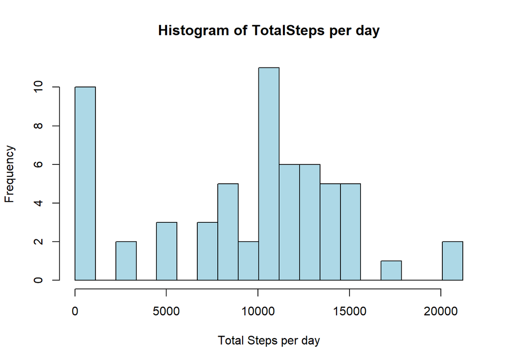

```r
dailySteps <- activity %>% group_by(date) %>% summarise(TotalSteps = sum(steps, na.rm = TRUE))
breaks <- seq(from = min(dailySteps$TotalSteps),
              to = max(dailySteps$TotalSteps),
              length.out = 20
)
hist(dailySteps$TotalSteps,main = 'Histogram of TotalSteps per day',
     breaks = breaks,col = 'lightblue',
     xlab = 'Total Steps per day'
)
```

The **mean** and **median** of the total number of steps taken each day:

```r
summarytbl <- summary(dailySteps$TotalSteps)
TS_mean <- summarytbl['Mean']
TS_median <- summarytbl['Median']
summarytbl
```

```
##    Min. 1st Qu.  Median    Mean 3rd Qu.    Max.
##       0    6778   10395    9354   12811   21194
```

## What is the average daily activity pattern?

Make a time series plot (i.e. type = “l”) of the 5-minute interval (x-axis) and the average number of steps taken, averaged across all days (y-axis)

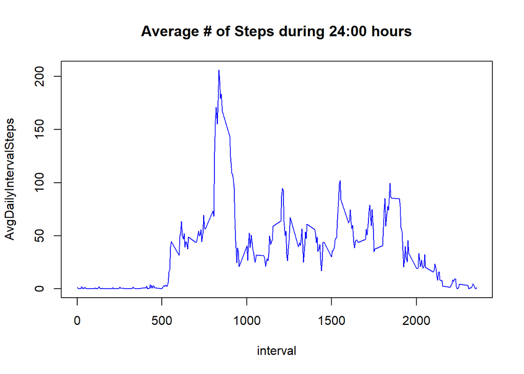

```r
dailyIntervalSteps <- activity %>% group_by(interval) %>% summarise(AvgDailyIntervalSteps = mean(steps, na.rm = TRUE))
with(dailyIntervalSteps,plot(x = interval, y = AvgDailyIntervalSteps,
                             type = 'l', col ='blue',
                             main = "Average # of Steps during 24:00 hours"
)
)
```

To find the 5-min interval in which the maximum number of steps take place across all days, we search for the interval whose average steps over the days is the maximum across all other intervals This comes out to be the 5 minutes between 8:35 a.m. and 8:40 a.m. which is interval 104 out of the 288 intervals per day ( 24hrs x 12 5min-interval/hr = 288)

```r
dailyIntervalSteps[which.max(dailyIntervalSteps$AvgDailyIntervalSteps),]
```

```
## # A tibble: 1 × 2
##   interval AvgDailyIntervalSteps
##      <dbl>                 <dbl>
## 1      835                  206.
```

## Imputing missing values

The total number of missing values in the field *steps* in the dataset **activity** is calculated by first creating a logical vector that computes a TRUE when steps value is NA and FALSE otherwise. Then uses the table function that reports the sum of all FALSE( not NA) and TRUE (NA) entries as shown below

```r
stepsV <- activity$steps
missing <- is.na(stepsV)
table(missing)
```

```
## missing
## FALSE  TRUE
## 15264  2304
```

```r
# indecies of missing values
indexOfNA <- which(missing == TRUE)
```

The missing value in a specific 5-min interval will be replaced by the mean of the 5-min interval calculated across all days

To do that, we will use the logical vector previously calculated **missing** in order to identify which row / observation where the steps needs to be filled by the corresponding similar 5-min interval slot from table **dailyIntervalSteps** The indices are stored in **indexOFNA**

The trick is to calculate the modulo of the interval number by 288 (which is the remainder of the division by 288). Each 288 intervals represent a full day and the remainder would then provide the interval number of that observation within that day. So rows 289 to 576 should correspond to 1 to 288. So if you take rows from 1 to 288, you need to get corresponding 1 to 288. Using modulo 288 will achieve that objective except that it wouldn’t work for 288 as you will get a remainder of 0. Consequently, 288 and any multiple of it will be replaced by 288 when extracting the average value of steps for that interval; which is the last 5 minute interval in a day. Moreover, we will make a copy of the activity table and fill the NAs there in order not to modify the raw dataset. We will call the copy : **activity_imu** i.e. activity with imputed missing values

```r
activity_imv <- activity
# find all the observation row numbers where the steps are NA
indexOfNA <- which(missing == TRUE)
# cycle through a loop of all the records with steps -> NA and replace their
# value with the corresponding average for the same time slot from dailyIntervalSteps
```

Missing values before imputing:

```r
table(is.na(activity_imv$steps))
```

```
##
## FALSE  TRUE
## 15264  2304
```

Replacing the NA values:

```r
i <- 0L
for (r in indexOfNA) {
        rSlot <- if(as.integer(r %% 288) != 0){
                as.integer(r %% 288)
        } else {
                288
        }
        i <- i +1L
        activity_imv[as.integer(r),'steps'] <- dailyIntervalSteps[rSlot,'AvgDailyIntervalSteps']
        # uncomment below code if you would like to see the first 300 rows how their NA were filled
        # if (i < 300) { print(paste('r=',r,' rSlot =',rSlot,'activity steps filled by =',activity_imv[as.integer(r),'steps']) )
        # } else if(i == 301){
        #                 print(activity_imv[1:301,], n = 301)
        #         }
}
```

NA steps of the 2304 records have been filled. If you want to verify, please uncomment the print statement shown below:

```r
# print(activity_imv[indexOfNA,],n = 2304)
```

Missing values after imputing are not present as shown below:

```r
table(is.na(activity_imv$steps))
```

```
##
## FALSE
## 17568
```